# Optimization

## Rosenbrock function

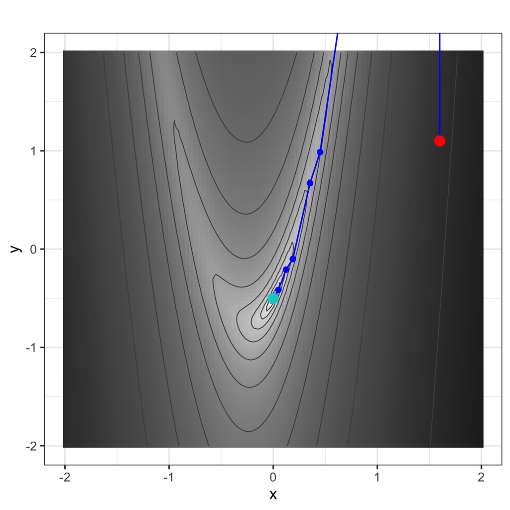

```r
rb = mk_rosenbrock()
opt = newtons_method_damped(c(1.6, 1.1), rb$f, rb$grad, rb$hess)
plot_2d_traj(c(-2, 2), c(-2, 2), rb$f, traj = opt)
```

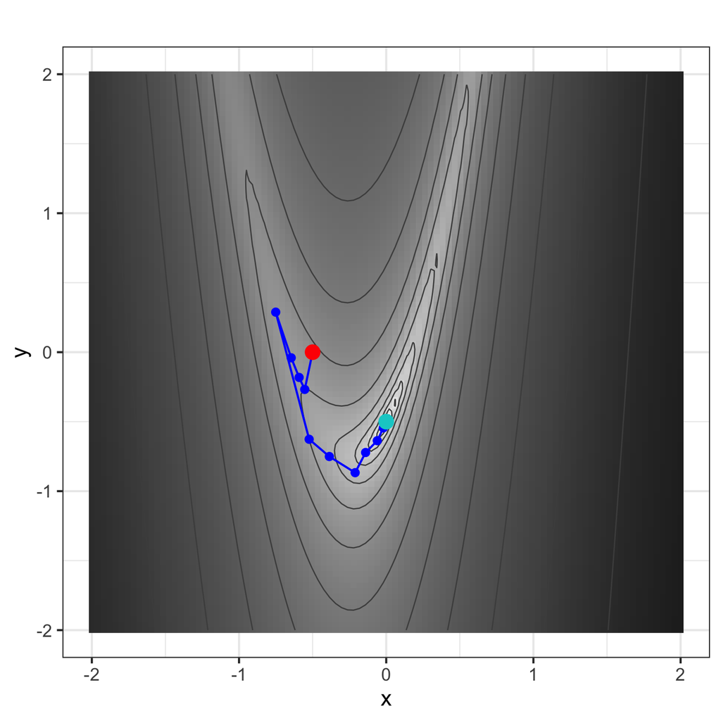

```r
rb = mk_rosenbrock()
opt = newtons_method_damped(c(-0.5, 0), rb$f, rb$grad, rb$hess)
plot_2d_traj(c(-2, 2), c(-2, 2), rb$f, traj = opt)
```

## Limitations of Newton’s Method

- Requires both the gradient *and* Hessian - second derivatives may be unavailable or expensive to compute
- Storing the $n \times n$ Hessian costs $O(n^2)$ memory and inverting it costs $O(n^3)$ per step - impractical for large $n$
- Can diverge or behave poorly if the Hessian is indefinite (not positive definite) away from the minimum
- Like GD, finds *local* minima and is sensitive to starting location
- Damping (backtracking) helps with robustness but adds cost and complexity

## Method Comparison

| Method | Convergence | Cost per step | Needs Hessian? | Notes |
| --- | --- | --- | --- | --- |
| Gradient Descent | Linear | $O(n)$ | No | Simple but slow on ill-conditioned problems |
| Newton’s Method | Quadratic | $O(n^3)$ | Yes | Fast near minimum; expensive for large $n$ |

Convergence rates matter in practice:

- *Linear* convergence means the error reduces by a constant factor each step - fine for well-conditioned problems, slow otherwise
- *Quadratic* convergence means the number of correct digits roughly doubles each step - Newton’s method achieves this near the minimum

# R’s `optim()`

## R’s `optim()`

R’s `optim()` function (from the `stats` package) provides a set of general-purpose optimization methods:

| Method | Description | Gradient | Bounds |
| --- | --- | --- | --- |
| `"Nelder-Mead"` | Nelder-Mead simplex (default) | ✗ | ✗ |
| `"BFGS"` | Quasi-Newton (Broyden-Fletcher-Goldfarb-Shanno) | Optional | ✗ |
| `"L-BFGS-B"` | Limited-memory BFGS with box constraints | Optional | ✓ |
| `"CG"` | Conjugate gradient (Fletcher-Reeves, Polak-Ribiere, or Beale-Sorenson) | Optional | ✗ |
| `"SANN"` | Simulated annealing (stochastic global optimization) | ✗ | ✗ |

- `"BFGS"` iteratively approximates the inverse Hessian - no Hessian needed, gradient optional
- `"L-BFGS-B"` stores only the last $m$ updates ($m \approx 5$-$20$), reducing memory from $O(n^2)$ to $O(mn)$
- The `optimx` package provides access to additional methods beyond those in `optim()`

## Nelder-Mead

This is a gradient free method that uses a series of simplexes which are used to iteratively bracket the minimum.

[interactive chart not shown]

This JS implementation comes from greg-rychlewski/nelder-mead

## `optim()` interface

```r
optim(par, fn, gr = NULL, method = "Nelder-Mead",
      lower = -Inf, upper = Inf, control = list(), hessian = FALSE)
```

Key arguments:

- `par` - initial parameter values (numeric vector)
- `fn` - function to minimize (must take a vector and return a scalar)
- `gr` - gradient function (optional; if `NULL`, finite differences are used)
- `method` - optimization method
- `lower`, `upper` - bounds (only for `"L-BFGS-B"`)
- `control` - list of control parameters (e.g. `maxit`, `reltol`, `fnscale`)
- `hessian` - if `TRUE`, return a numerically approximated Hessian

## Example - Well-conditioned quadratic

```r
q = mk_quad(0.7)
```

```r
optim(
  c(1.6, 1.1), q$f, q$grad,
  method = "BFGS"
)
```

```
$par
[1]  5.862023e-11 -4.031139e-11

$value
[1] 1.396753e-21

$counts
function gradient
      18       15

$convergence
[1] 0

$message
NULL
```

```r
optim(
  c(1.6, 1.1), q$f,
  method = "BFGS"
)
```

[output not shown]

```r
optim(
  c(1.6, 1.1), q$f, q$grad,
  method = "L-BFGS-B"
)
```

```
$par
[1] -9.813109e-10  1.897810e-08

$value
[1] 5.855701e-17

$counts
function gradient
       7        7

$convergence
[1] 0

$message
[1] "CONVERGENCE: REL_REDUCTION_OF_F <= FACTR*EPSMCH"
```

```r
optim(
  c(1.6, 1.1), q$f, q$grad,
  method = "CG"
)
```

```
$par
[1] 1.295347e-09 3.685591e-06

$value
[1] 2.196466e-12

$counts
function gradient
      45       23

$convergence
[1] 0

$message
NULL
```

```r
optim(
  c(1.6, 1.1), q$f,
  method = "Nelder-Mead"
)
```

```
$par
[1] -5.022501e-06  8.313814e-05

$value
[1] 1.125987e-09

$counts
function gradient
      71       NA

$convergence
[1] 0

$message
NULL
```

## Example - Rosenbrock

```r
rb = mk_rosenbrock()
```

```r
optim(
  c(1.6, 1.1), rb$f,
  method = "BFGS"
)
```

```
$par
[1] -1.561887e-05 -5.000314e-01

$value
[1] 1.952282e-09

$counts
function gradient
      47       16

$convergence
[1] 0

$message
NULL
```

```r
optim(
  c(1.6, 1.1), rb$f, rb$grad,
  method = "BFGS"
)
```

```
$par
[1]  1.10249e-12 -5.00000e-01

$value
[1] 1.049227e-23

$counts
function gradient
      49       20

$convergence
[1] 0

$message
NULL
```

```r
optim(
  c(1.6, 1.1), rb$f, rb$grad,
  method = "L-BFGS-B"
)
```

```
$par
[1]  1.543156e-09 -5.000000e-01

$value
[1] 3.58706e-17

$counts
function gradient
      26       26

$convergence
[1] 0

$message
[1] "CONVERGENCE: REL_REDUCTION_OF_F <= FACTR*EPSMCH"
```

```r
optim(
  c(1.6, 1.1), rb$f, rb$grad,
  method = "CG"
)
```

```
$par
[1]  0.0009579996 -0.4978521443

$value
[1] 7.220552e-06

$counts
function gradient
     356      101

$convergence
[1] 1

$message
NULL
```

```r
optim(
  c(1.6, 1.1), rb$f,
  method = "Nelder-Mead"
)
```

```
$par
[1]  0.0008425688 -0.4982432286

$value
[1] 5.7551e-06

$counts
function gradient
     119       NA

$convergence
[1] 0

$message
NULL
```

## Comparing methods - fixed start

- Implementation
- Results

```r
cost_funcs = list(
  "Well-cond quad" = mk_quad(0.7),
  "Ill-cond quad" = mk_quad(0.02),
  "Rosenbrock" = mk_rosenbrock()
)

results_fixed = bench::press(
  cost_func = names(cost_funcs) |> forcats::as_factor(),
  {
    fns = cost_funcs[[cost_func]]
    bench::mark(
      "Nelder-Mead"   = optim(c(1.6, 1.1), fns$f, fns$grad, method = "Nelder-Mead"),
      "BFGS"          = optim(c(1.6, 1.1), fns$f, fns$grad, method = "BFGS"),
      "BFGS w/o Grad" = optim(c(1.6, 1.1), fns$f,           method = "BFGS"),
      "CG"            = optim(c(1.6, 1.1), fns$f, fns$grad, method = "CG"),
      "L-BFGS-B"      = optim(c(1.6, 1.1), fns$f, fns$grad, method = "L-BFGS-B"),
      check = FALSE
    )
  }
)
```

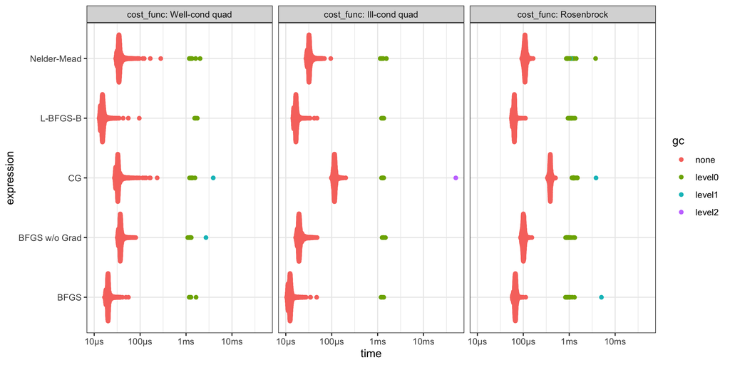

## Comparing methods - random start

- Implementation
- Results

```r
results_random = bench::press(
  cost_func = names(cost_funcs) |> forcats::as_factor(),
  x0 = runif(200, -2, 2) |> matrix(ncol=2) |> apply(1,c, simplify = FALSE),
  {
    fns = cost_funcs[[cost_func]]
    x0 = unlist(x0)
    bench::mark(
      "Nelder-Mead"   = optim(x0, fns$f, fns$grad, method = "Nelder-Mead"),
      "BFGS"          = optim(x0, fns$f, fns$grad, method = "BFGS"),
      "BFGS w/o Grad" = optim(x0, fns$f,           method = "BFGS"),
      "CG"            = optim(x0, fns$f, fns$grad, method = "CG"),
      "L-BFGS-B"      = optim(x0, fns$f, fns$grad, method = "L-BFGS-B"),
      check = FALSE,
      iterations = 1
    )
  }
) |>
  select(-x0)
```

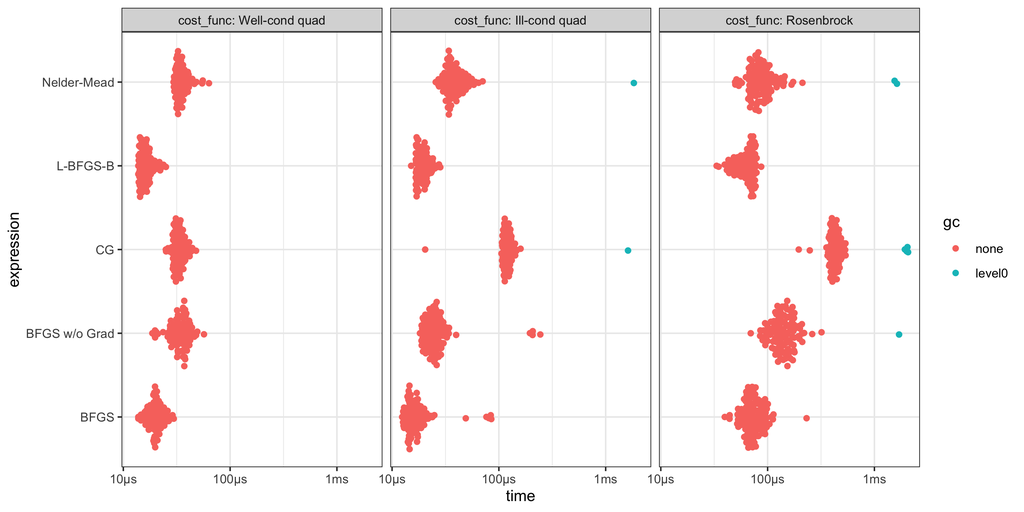

## Some general advice

- Having access to the gradient is almost always helpful / necessary
- Having access to the Hessian can be helpful, but usually does not significantly improve things
- The curse of dimensionality is real - everything gets much harder as $n$ grows
  - Be careful with tolerance settings - what is “close enough” in 2d may not be close enough in 1000d
- In general, **BFGS** or **L-BFGS** are a good place to start for most problems (either well- or ill-conditioned)